# Survey Results

**Work in progress**

The survey was conducted in the population of Aarhus, Denmark, and includes questions about beliefs, belief certainties, and preferences on five national topics: security, economics, welfare, immigration, and climate change. On Aarhus local topics, it has the ten most relevant questions from the Voting Advice Application (Kandidattest) for the municipal election.

```r
library(tidyverse)
library(ggstats)
library(ggExtra)
library(corrr)
library(scales)
library(gt)
library(patchwork)
library(glue)
# data <- read_csv("survey_responses_ENG_TRANS.csv")
data <- read_csv("OneDrive/Aarhus Survey Data/survey_responses_ENG_TRANS.csv")
cand <- read_csv("OneDrive/Aarhus Survey Data/aarhus_candidates_local_2025.csv")
# cross-walk Qx - ALCLx
crosswalk <- tribble(
  ~Q    , ~ALCL    ,
  "Q6"  , "ALCL1"  ,
  "Q5"  , "ALCL2"  ,
  "Q1"  , "ALCL3"  ,
  "Q8"  , "ALCL4"  ,
  "Q17" , "ALCL5"  ,
  "Q21" , "ALCL6"  ,
  "Q22" , "ALCL7"  ,
  "Q23" , "ALCL8"  ,
  "Q24" , "ALCL9"  ,
  "Q25" , "ALCL10"
)
```

## 1 National Topics

On national topics there were one questions each about beliefs, belief certainties, and preferences on security, economics, welfare, immigration, and climate change

### 1.1 Belief, Certainty, Preference Questions

```r
library(tidyverse)
nat_domains_questions <- tibble(
  Label = fct_inorder(c("NSEC", "NECN", "NWLF", "NIMG", "NCLM")),
  Topic = fct_inorder(c(
    "Security",
    "Economics",
    "Welfare",
    "Immigration",
    "Climate Change"
  )),
  Belief_q = c(
    "Denmark currently faces serious security threats.",
    "Economic inequality in Denmark is too high.",
    "People in Denmark who need public support do not always receive enough help.",
    "Immigrants in Denmark are not integrating well into society.",
    "Climate change poses an urgent threat to Denmark."
  ),
  Preference_q = c(
    "Denmark spends too much money on supporting Ukraine in the war against Russia.",
    "The tax for the highest incomes must be raised",
    "The transfer income for the poorest cash assistance recipients must be increased.",
    "More foreign labor from countries outside Europe and North America must be opened up.",
    "Nuclear power on Danish soil must be part of the energy supply in the long term."
  )
)
nat_domains_questions |>
  select(Label, Topic, Belief_q, Preference_q) |>
  knitr::kable(
    col.names = c("Label", "Topic", "Belief Question", "Preference Question")
  )
```

Table 1: Belief and preference questions on national topics

| Label | Topic | Belief Question | Preference Question |
| --- | --- | --- | --- |
| NSEC | Security | Denmark currently faces serious security threats. | Denmark spends too much money on supporting Ukraine in the war against Russia. |
| NECN | Economics | Economic inequality in Denmark is too high. | The tax for the highest incomes must be raised |
| NWLF | Welfare | People in Denmark who need public support do not always receive enough help. | The transfer income for the poorest cash assistance recipients must be increased. |
| NIMG | Immigration | Immigrants in Denmark are not integrating well into society. | More foreign labor from countries outside Europe and North America must be opened up. |
| NCLM | Climate Change | Climate change poses an urgent threat to Denmark. | Nuclear power on Danish soil must be part of the energy supply in the long term. |

Respondents assess their beliefs and preferences on a scale from 0 (*Strongly disagree*) to 10 (*Strongly agree*), 5 was labeled as *Neither agree nor disagree*.

For all belief questions, respondents were additionally asked

> How certain are you about your response to the previous statement?

Respondents assess their certainty on a scale from 0 (*I could easily change my mind*) to 10 (*I am completely certain about my view.*).

### 1.2 Belief, Uncertainty, and Preference Distributions

Insights:

- For all topics, beliefs are more skewed towards agreement than preferences.
- Certainty about the beliefs is generally high.
- Preferences have the typical *pentamodal* distribution spanning all possible opinions with peaks at the two extremes in the middle and two off-central moderate opinions (see Gestefeld et al. 2022). This maybe caused by some condensing around focal or socially emergent values.
- Taking standard deviation (SD) as a measure of polarization, beliefs preferences are most polarized with Climate Change most and Immigration preferences least polarized. Beliefs are generally less polarized (partly a consequence of the positive bias) with Economic belief being most and Security belief being least polarized. On uncertainty there is the least variation in Mean and SD over all five topics.

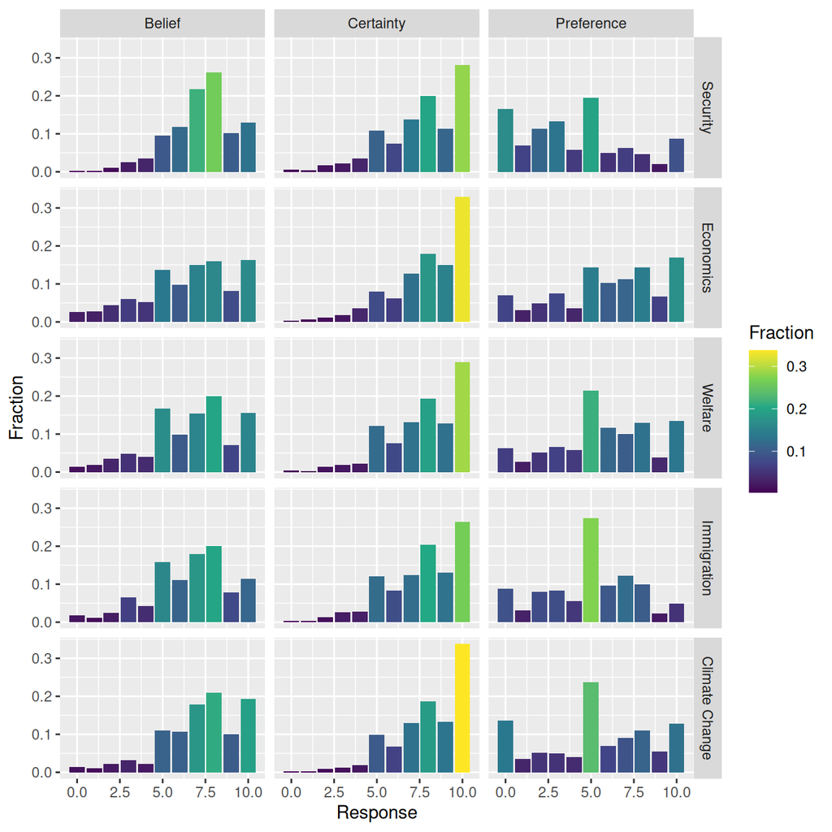

Figure 1: Belief, certainty, and preference distributions for the five national topics. Questions in Table 1.

```r
data_nat_long <- data |>
  pivot_longer(
    c(ends_with("_B"), ends_with("_P"), ends_with("_BCRT")),
    names_to = "Variable",
    values_to = "Response"
  ) |>
  mutate(
    Label = word(Variable, 1, sep = "_"),
    Type = word(Variable, 2, sep = "_") |>
      str_replace("BCRT", "Certainty") |>
      str_replace("B", "Belief") |>
      str_replace("P", "Preference")
  ) |>
  select(-Variable) |>
  left_join(nat_domains_questions, by = "Label")
data_nat_long_fractions <- data_nat_long |>
  count(Response, Label, Topic, Type, Preference_q, Belief_q) |>
  mutate(Fraction = n / sum(n), .by = c(Topic, Type))
data_nat_long_fractions |>
  ggplot(aes(x = Response, y = Fraction, fill = Fraction)) +
  geom_col() +
  scale_fill_viridis_c() +
  facet_grid(Topic ~ Type)
```

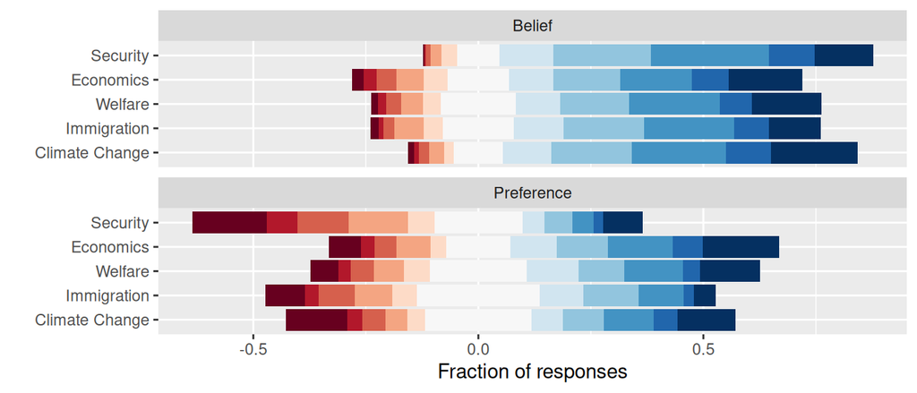

Figure 2: Belief and preference distributions in Likert-scale plotting. Questions in Table 1.

```r
data_nat_long_fractions |>
  filter(Type != "Certainty") |>
  ggplot(aes(
    y = Topic |> fct_rev(),
    fill = Response |> as.factor(),
    x = Fraction
  )) +
  geom_col(position = "likert") +
  facet_wrap(~Type, ncol = 1) +
  scale_fill_brewer(type = "div", palette = "RdBu") +
  labs(x = "Fraction of responses", y = "") +
  guides(fill = "none")
```

```r
data_nat_long |>
  summarise(
    Mean = mean(Response),
    SD = sd(Response),
    .by = c(Topic, Type)
  ) |>
  pivot_wider(
    names_from = Type,
    values_from = c(Mean, SD),
    names_sep = " ",
    names_vary = "slowest"
  ) |>
  gt() |>
  fmt_number(columns = everything(), decimals = 2) |>
  data_color(
    columns = starts_with("Mean"),
    palette = "BuGn",
    method = "numeric",
    domain = c(3.5, 9.5)
  ) |>
  data_color(
    columns = starts_with("SD"),
    palette = "OrRd",
    method = "numeric",
    domain = c(1, 3.5)
  ) |>
  opt_interactive()
```

Table 2

| Topic | Mean Belief | SD Belief | Mean Preference | SD Preference | Mean Certainty | SD Certainty |
| --- | --- | --- | --- | --- | --- | --- |
| Security | 7.252208047105 | 1.87008886141841 | 4.07163886162905 | 3.03609108553533 | 7.64082433758587 | 2.19181853149532 |
| Economics | 6.46319921491658 | 2.68067558314726 | 6.07065750736016 | 3.00930329898059 | 7.94406280667321 | 2.12197122185609 |
| Welfare | 6.68694798822375 | 2.42513370466544 | 5.76447497546614 | 2.805319461847 | 7.7360157016683 | 2.11784174524596 |
| Immigration | 6.57605495583906 | 2.32287161826341 | 4.95780176643768 | 2.61910493941176 | 7.62512266928361 | 2.14979252886354 |
| Climate Change | 7.18743866535819 | 2.29186637658705 | 5.33169774288518 | 3.17187514075679 | 8.00981354268891 | 2.01368155947256 |

Belief, certainty, and preference summary statistics for the five national topics. Questions in Table 1.

### 1.3 Belief-Preference Relation

Insights:

- On **economics** and **welfare** the belief-preference relation is **strongly positively** correlated. (Who believes economic inequality is too high strongly tends to agree that the tax for the highest incomes must be raised; and who believes people who need public support do not always receive enough help tends to agree that the transfer income for the poorest cash assistance recipients must be increased.)
- On **security** and **climate change** the belief-preference relation is **moderately negatively** correlated. (Who believes Denmark faces serious security threats is tends to disagree that Denmark spends too much money on supporting Ukraine; and who believes climate change poses an urgent threat to Denmark tends to disagree that nuclear power must be part of the energy supply.)
- On **immigration** the belief-preference relation is essentially uncorrelated. (The belief that immigrants are not integrating well does not predict the preference for opening up more foreign labor non-European countries.)

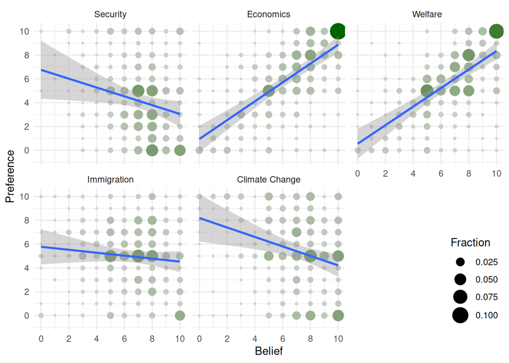

Figure 3: Belief-preference relation for the five national topics. Questions in Table 1.

```r
data_nat_belpref_fraction <- data_nat_long |>
  filter_out(Type == "Certainty") |>
  select(userId, Type, Topic, Response) |>
  pivot_wider(names_from = Type, values_from = Response) |>
  count(Belief, Preference, Topic) |>
  mutate(Fraction = n / sum(n), .by = Topic)

data_nat_belpref_fraction |>
  ggplot(aes(x = Belief, y = Preference)) +
  geom_point(aes(size = Fraction, color = Fraction)) +
  geom_smooth(method = "lm", aes(weight = Fraction), formula = 'y ~ x') +
  scale_size_area(max_size = 7) +
  scale_color_gradient(high = "darkgreen", low = "lightgray") +
  scale_x_continuous(breaks = seq(0, 10, by = 2)) +
  scale_y_continuous(breaks = seq(0, 10, by = 2)) +
  facet_wrap(~Topic) +
  theme_minimal() +
  guides(color = "none") +
  theme(legend.position = c(1, 0), legend.justification = c(1, 0))
```

### 1.4 Belief Extremity and Certainty

Belief extremity is calculated as the absolute distance of the belief response from the neutral point (5).

```r
data_nat_extr <- data_nat_long |>
  filter_out(Type == "Preference") |>
  pivot_wider(names_from = Type, values_from = Response) |>
  mutate(Belief_Extremity = abs(5 - Belief), .by = Topic)
data_nat_extr_fraction <- data_nat_extr |>
  count(Belief_Extremity, Certainty, Topic) |>
  mutate(Fraction = n / sum(n), .by = Topic)
```

Insights:

- Belief extremity and certainty are positively related for all topics in a very similar way. The overall correlation is 0.56.

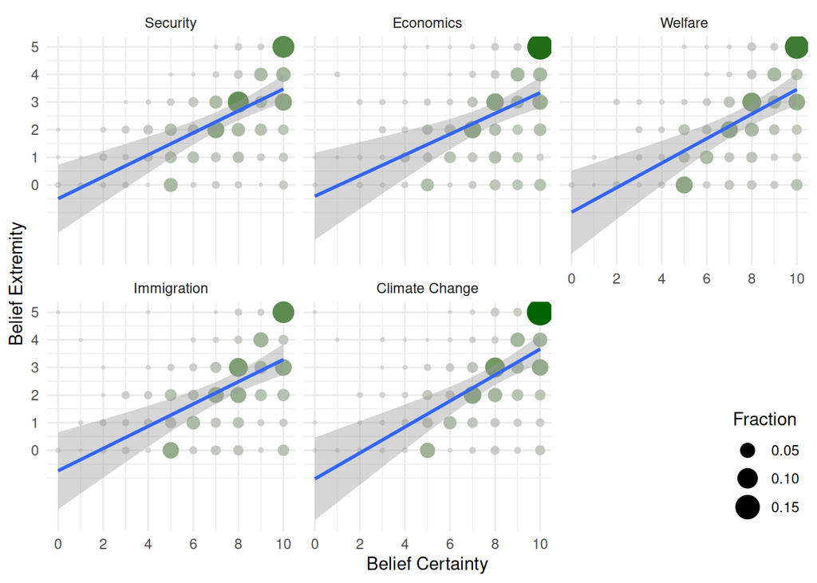

```r
data_nat_extr_fraction |>
  ggplot(aes(x = Certainty, y = Belief_Extremity)) +
  geom_point(aes(size = Fraction, color = Fraction)) +
  geom_smooth(aes(weight = Fraction), method = "lm", formula = 'y ~ x') +
  scale_size_area(max_size = 7) +
  scale_color_gradient(high = "darkgreen", low = "lightgray") +
  scale_x_continuous(breaks = seq(0, 10, by = 2)) +
  scale_y_continuous(breaks = seq(0, 5, by = 1)) +
  facet_wrap(~Topic) +
  labs(
    x = "Belief Certainty",
    y = "Belief Extremity"
  ) +
  theme_minimal() +
  guides(color = "none") +
  theme(legend.position = c(1, 0), legend.justification = c(1, 0))
```

### 1.5 Principal Component Analysis on national topics

#### 1.5.1 Beliefs

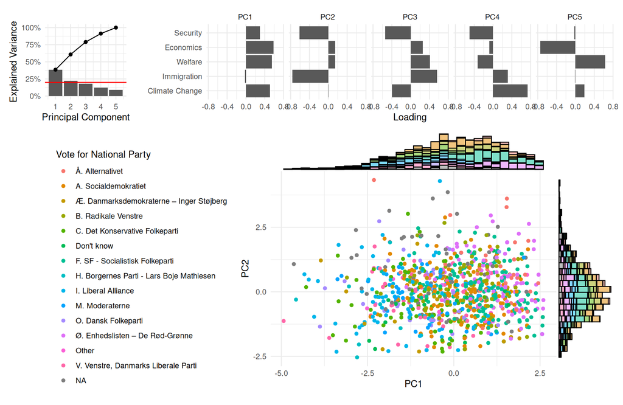

Figure 4: Principal Component Analysis on beliefs for the five national topics. Questions in Table 1.

```r
prcomp_bel_nat <- data_nat_long |>
  filter(Type == "Belief") |>
  select(userId, Topic, Response) |>
  pivot_wider(names_from = Topic, values_from = Response) |>
  select(-userId) |>
  prcomp(scale. = TRUE)
prcomp_bel_nat$x <- prcomp_bel_nat$x |>
  as_tibble() |>
  bind_cols(data)

prcomp_plot <- function(
  pr,
  color_by = VOTE_NAT_PRTY,
  color_by_label = "Vote National Party",
  plot_heights = c(1, 3.5)
) {
  rel_pcs <- sum(pr$sdev > 1)
  g1 <- tibble(
    explVar = pr$sdev^2 / sum(pr$sdev^2),
    cumexplVar = cumsum(pr$sdev^2 / sum(pr$sdev^2))
  ) |>
    ggplot(aes(x = 1:length(explVar))) +
    geom_col(aes(y = explVar)) +
    geom_point(aes(y = cumexplVar)) +
    geom_line(aes(y = cumexplVar)) +
    geom_hline(yintercept = 1 / length(pr$sdev), color = "red") +
    scale_y_continuous(labels = percent_format(accuracy = 1)) +
    labs(
      x = "Principal Component",
      y = "Explained Variance",
      #title = glue("{rel_pcs} PCs explain more variance than average")
    ) +
    theme_minimal() +
    theme(plot.title.position = "plot")
  g2 <- pr$rotation |>
    as_tibble() |>
    mutate(Topic = fct_inorder(pr$rotation |> row.names()) |> fct_rev()) |>
    pivot_longer(starts_with("PC"), names_to = "PC", values_to = "Loading") |>
    mutate(PC = fct_inorder(PC)) |>
    ggplot(aes(x = Loading, y = Topic)) +
    geom_col() +
    facet_wrap(~PC, ncol = 5) +
    labs(
      x = "Loading",
      y = ""
    ) +
    theme_minimal()
  g3 <- pr$x |>
    as_tibble() |>
    ggplot(aes(x = PC1, y = PC2, color = {{ color_by }})) +
    geom_point(alpha = 1) +
    labs(
      x = "PC1",
      y = "PC2",
      color = color_by_label
    ) +
    theme_minimal() +
    theme(legend.position = "left")
  (g1 + g2 + plot_layout(widths = c(1, 5))) /
    wrap_elements(g3 |> ggMarginal(type = "histogram", groupFill = TRUE)) +
    plot_layout(heights = plot_heights)
}
prcomp_plot(prcomp_bel_nat, VOTE_NAT_PRTY, "Vote for National Party")
```

#### 1.5.2 Preferences

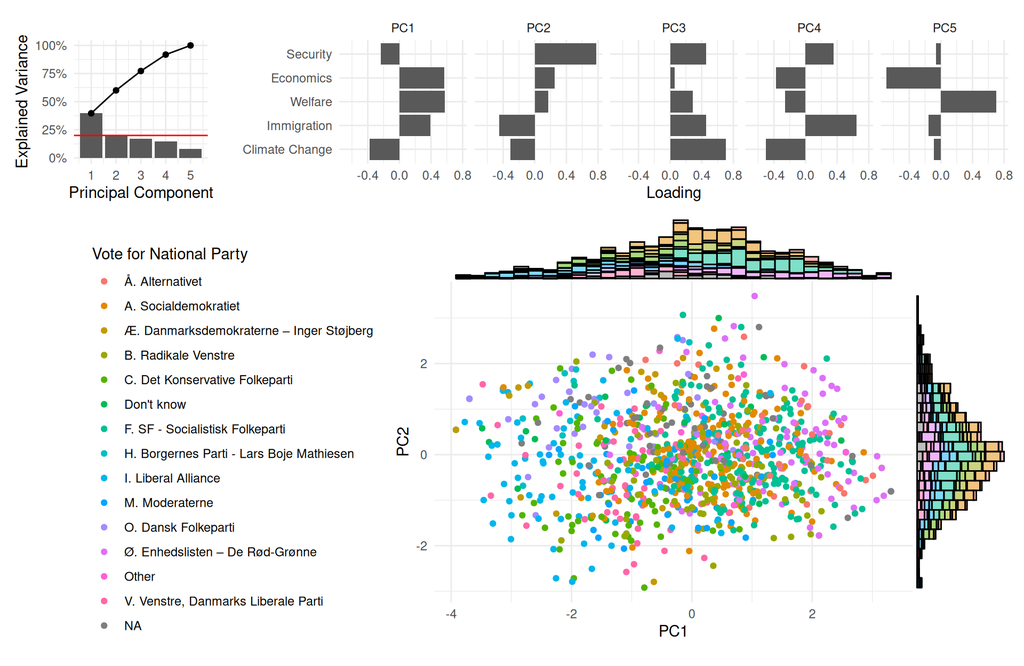

Figure 5: Principal Component Analysis on preferences for the five national topics. Questions in Table 1.

```r
prcomp_pref_nat <- data_nat_long |>
  filter(Type == "Preference") |>
  select(userId, Topic, Response) |>
  pivot_wider(names_from = Topic, values_from = Response) |>
  select(-userId) |>
  prcomp(scale. = TRUE)
prcomp_pref_nat$x <- prcomp_pref_nat$x |>
  as_tibble() |>
  bind_cols(data)
prcomp_plot(prcomp_pref_nat, VOTE_NAT_PRTY, "Vote for National Party")
```

## 2 Local preferences

The survey included the ten most relevant questions from the Voting Advice Application (Kandidattest) for the municipal election. The This application is used by voters to find out which local candidate or party matches their preferences best.

The Voting Advice Application used a four-point scale for the local preference questions with $-2$ (*Strongly disagree*), $-1$ (*Disagree*), $+1$ (*Agree*), and $+2$ (*Strongly agree*). In our survey also $0$ being *Neither agree nor disagree* was included.

```r
loc_domains_questions <- tibble(
  Label = paste0("ALCL", 1:10),
  Preference_q = c(
    "Municipal tax in Aarhus Municipality must be raised, and the money must be spent on better welfare.",
    "It is possible to save money in the public sector without affecting public welfare.",
    "More tasks in the public sector must be solved by private companies.",
    "Aarhus Municipality must make it cheaper to run a business.",
    "Aarhus Municipality must prioritize that school pupils are mixed according to ethnicity and social background.",
    "The politicians must prevent the construction of mosques.",
    "More parking spaces must be established in Aarhus Municipality.",
    "The city council's temporary stop for the expansion of Aarhus Harbor must be made permanent.",
    "Car traffic in Aarhus city center must be limited, for example through one-way directions, speed reductions and a zero-emission zone.",
    "The municipality must continue with the plans for the new football stadium in Kongelunden, even if the costs rise again."
  ),
  Preference_s = c(
    "Raise taxes",
    "Save public money",
    "Privatize",
    "Cheaper Business",
    "Mixed schools",
    "No mosques",
    "More parking",
    "Harbor stop",
    "Limit cars",
    "Stadium"
  )
)
loc_domains_questions_danish <- tibble(
  Label = paste0("ALCL", 1:10),
  Preference_q = c(
    "Kommuneskatten i Aarhus Kommune skal hæves, og pengene skal bruges på bedre velfærd.",
    "Det er muligt at spare penge i den offentlige sektor uden at påvirke den offentlige velfærd.",
    "Flere opgaver i den offentlige sektor skal løses af private virksomheder.",
    "Aarhus Kommune skal gøre det billigere at drive virksomhed.",
    "Aarhus Kommune skal prioritere, at skoleelever blandes på tværs af etnicitet og social baggrund.",
    "Politikerne skal forhindre opførelsen af moskéer.",
    "Der skal etableres flere parkeringspladser i Aarhus Kommune.",
    "Byrådets midlertidige stop for udvidelsen af Aarhus Havn skal gøres permanent.",
    "Biltrafikken i Aarhus centrum skal begrænses, for eksempel gennem ensretninger, hastighedsnedsættelser og en nulemissionszone.",
    "Kommunen skal fortsætte planerne om det nye fodboldstadion i Kongelunden, selv hvis omkostningerne stiger igen."
  )
)

loc_domains_questions |>
  select(Label, Preference_s, Preference_q) |>
  knitr::kable(
    col.names = c("Label", "Short", "Preference Question")
  )
```

Table 3: Local preference questions.

| Label | Short | Preference Question |
| --- | --- | --- |
| ALCL1 | Raise taxes | Municipal tax in Aarhus Municipality must be raised, and the money must be spent on better welfare. |
| ALCL2 | Save public money | It is possible to save money in the public sector without affecting public welfare. |
| ALCL3 | Privatize | More tasks in the public sector must be solved by private companies. |
| ALCL4 | Cheaper Business | Aarhus Municipality must make it cheaper to run a business. |
| ALCL5 | Mixed schools | Aarhus Municipality must prioritize that school pupils are mixed according to ethnicity and social background. |
| ALCL6 | No mosques | The politicians must prevent the construction of mosques. |
| ALCL7 | More parking | More parking spaces must be established in Aarhus Municipality. |
| ALCL8 | Harbor stop | The city council’s temporary stop for the expansion of Aarhus Harbor must be made permanent. |
| ALCL9 | Limit cars | Car traffic in Aarhus city center must be limited, for example through one-way directions, speed reductions and a zero-emission zone. |
| ALCL10 | Stadium | The municipality must continue with the plans for the new football stadium in Kongelunden, even if the costs rise again. |

### 2.1 Parties

Party preference profiles (ten ALCL survey items) can be derived from the candidates and from the citizens which reposndet in the survey.

```r
parties_cand <- cand |>
  mutate(
    party_full = party,
    party = party_full |>
      fct_relevel(sort(levels(party_full))) |>
      fct_lump_min(6, other_level = "Other Party") |>
      fct_other(
        drop = "N. Nej til privatisering af kommunale veje",
        other_level = "Other Party"
      ) |>
      fct_relevel("Other Party", after = Inf)
  ) |>
  pivot_longer(
    cols = paste0("Q", 1:26),
    names_to = "Name",
    values_to = "Preference"
  ) |>
  left_join(crosswalk, by = c("Name" = "Q")) |>
  filter_out(is.na(ALCL)) |>
  summarize(
    Mean = mean(Preference, na.rm = TRUE),
    SD = sd(Preference, na.rm = TRUE),
    N_cand = n(),
    .by = c(party, ALCL)
  ) |>
  left_join(
    loc_domains_questions |> select(Label, Preference_s),
    by = c("ALCL" = "Label")
  ) |>
  rename(Description = Preference_s) |>
  mutate(ALCL = factor(ALCL, levels = paste0("ALCL", 1:10))) |>
  arrange(party, ALCL)
parties_cand |>
  select(party, ALCL, Description, Mean, N_cand) |>
  pivot_wider(
    names_from = c(ALCL, Description),
    values_from = c(Mean),
    names_sep = "<br>"
  ) |>
  gt() |>
  tab_header(
    title = "Local party profiles based on candidate preferences"
  ) |>
  cols_label(
    party = "Party",
    N_cand = "Candidates"
  ) |>
  cols_label_with(starts_with("ALCL"), md) |>
  fmt_number(columns = everything(), decimals = 2) |>
  fmt_number(columns = c(N_cand), decimals = 0) |>
  data_color(
    columns = starts_with("ALCL"),
    palette = "RdBu",
    method = "numeric",
    domain = c(-2, 2)
  ) |>
  cols_width(
    party ~ px(200),
    N_cand ~ px(100),
    starts_with("ALCL") ~ px(85)
  ) |>
  tab_footnote(
    "Only parties with at least six candidates and more than 2% respondents in the people survey are included."
  ) |>
  opt_interactive(use_pagination = FALSE)
```

Table 4: Local parties averaged candidate preference profile.

Local party profiles based on candidate preferences

| Party | Candidates | <span data-qmd-base64="QUxDTDE8YnI+UmFpc2UgdGF4ZXM="><span class='gt_from_md'>ALCL1<br>Raise taxes</span></span> | <span data-qmd-base64="QUxDTDI8YnI+U2F2ZSBwdWJsaWMgbW9uZXk="><span class='gt_from_md'>ALCL2<br>Save public money</span></span> | <span data-qmd-base64="QUxDTDM8YnI+UHJpdmF0aXpl"><span class='gt_from_md'>ALCL3<br>Privatize</span></span> | <span data-qmd-base64="QUxDTDQ8YnI+Q2hlYXBlciBCdXNpbmVzcw=="><span class='gt_from_md'>ALCL4<br>Cheaper Business</span></span> | <span data-qmd-base64="QUxDTDU8YnI+TWl4ZWQgc2Nob29scw=="><span class='gt_from_md'>ALCL5<br>Mixed schools</span></span> | <span data-qmd-base64="QUxDTDY8YnI+Tm8gbW9zcXVlcw=="><span class='gt_from_md'>ALCL6<br>No mosques</span></span> | <span data-qmd-base64="QUxDTDc8YnI+TW9yZSBwYXJraW5n"><span class='gt_from_md'>ALCL7<br>More parking</span></span> | <span data-qmd-base64="QUxDTDg8YnI+SGFyYm9yIHN0b3A="><span class='gt_from_md'>ALCL8<br>Harbor stop</span></span> | <span data-qmd-base64="QUxDTDk8YnI+TGltaXQgY2Fycw=="><span class='gt_from_md'>ALCL9<br>Limit cars</span></span> | <span data-qmd-base64="QUxDTDEwPGJyPlN0YWRpdW0="><span class='gt_from_md'>ALCL10<br>Stadium</span></span> |
| --- | --- | --- | --- | --- | --- | --- | --- | --- | --- | --- | --- |
| Å. Alternativet | 9 | 0.571428571428571 | -0.142857142857143 | -1.14285714285714 | -0.857142857142857 | 0.285714285714286 | -1.71428571428571 | -1.85714285714286 | 2 | 2 | -0.857142857142857 |
| A. Socialdemokratiet | 22 | -0.421052631578947 | -0.736842105263158 | -1.21052631578947 | -0.421052631578947 | 1.15789473684211 | -0.368421052631579 | -0.105263157894737 | 1 | 1.21052631578947 | 0.789473684210526 |
| Æ. Danmarksdemokraterne ‒ Inger Støjberg | 11 | -0.9 | 0.7 | 1.1 | 0.9 | -1.1 | 2 | 1.8 | 1.1 | -1.9 | -1 |
| B. Radikale Venstre | 18 | -0.8125 | 0.1875 | -0.1875 | 0.75 | -0.3125 | -1.1875 | -1.0625 | 0.9375 | 1.375 | 0.625 |
| C. Det Konservative Folkeparti | 17 | -1.5 | 1.0625 | 0.875 | 1.5 | -0.6875 | 0.5 | 1 | -0.0625 | -0.8125 | 1 |
| F. SF - Socialistisk Folkeparti | 25 | 1.52380952380952 | -1.52380952380952 | -1.47619047619048 | -0.523809523809524 | 1.04761904761905 | -1.23809523809524 | -0.904761904761905 | 1.42857142857143 | 1.61904761904762 | -0.238095238095238 |
| I. Liberal Alliance | 12 | -2 | 2 | 1.875 | 2 | -1.625 | 0.25 | 1.875 | 1 | -1.75 | 0 |
| M. Moderaterne | 6 | -1 | 0.333333333333333 | 1 | 1.33333333333333 | -1.33333333333333 | -0.5 | 0.333333333333333 | -0.5 | 0.333333333333333 | -0.166666666666667 |
| O. Dansk Folkeparti | 7 | -1.14285714285714 | 0.142857142857143 | 0.285714285714286 | 1.42857142857143 | -1.85714285714286 | 1.71428571428571 | 1.71428571428571 | -0.142857142857143 | -2 | -0.857142857142857 |
| Ø. Enhedslisten – De Rød-Grønne | 29 | 1.45454545454545 | -1.40909090909091 | -1.86363636363636 | -1.33333333333333 | -0.476190476190476 | -1.9 | -1.38095238095238 | 2 | 1.80952380952381 | -1.33333333333333 |

[output cut: 2 more lines]

Only parties with at least six candidates and more than 2% respondents in the people survey are included.